# Introduction

The first part of this note considers the case of a Solow growth model with a general, constant returns to scale, production function. The second part of the note looks at a special case of the Solow growth model for a case of a Cobb-Douglas production function.

# General Production Function

## Assumptions

Robert Solow, 1987 Nobel Memorial Prize in Economic Sciences, starts from a general production function, giving at any point in time output $Y_t$ as a function of inputs, capital $K_t$ and labor $L_t$:
$$Y_t=F\left(K_t,L_t\right).$$
A very important assumption is also **constant returns to scale** with respect to capital and labor, so that for any scaling factor $a$:
$$F(aK_t, aL_t) = aF(K_t, L_t).$$

For simplicity, we shall assume from now on that the quantity of labor is fixed with $L_t=L$, so that the production function becomes $Y_t=F(K_t, L)$. Because of constant returns to scale with respect to capital and labor (and setting $a=1/L$ in the previous expression), we have:
$$\frac{Y_t}{L}=F\left(\frac{K_t}{L},1\right)=f\left(\frac{K_t}{L}\right)$$
where $f$ is defined as a function of $F$ such that:
$$f(x)\equiv F(x,1).$$

An example of such a production function is the Cobb-Douglas production function, which we started studying in Lecture 1, and which we look at in the next section.

Robert Solow, in his 1956 contribution, abstracts from public saving, so that **total saving** at time $t$ equals **private saving** at time $t$, and both are denoted $S_{t}$, which also equals investment $I_{t}$ at time $t$ :
$$S_{t}=I_{t}.$$

Saving is assumed to be a constant fraction $s$ of output $Y_{t}$, and therefore:
$$S_{t}=sY_{t}.$$

This constant saving rate my seem a bit ad-hoc; it is. We will investigate more in detail the determinants of saving and consumption behavior in the next lectures. Depreciation of capital is given by a share $\delta$ (think for example that 8% of the capital stock depreciates each period; the rate of depreciation is much lower for structures, and much higher for computers). The capital stock evolves according to:

$$K_{t+1}=\left(1-\delta\right)K_{t}+I_{t}$$

## Solution

Replace investment in the previous equation and divide both sides by $L$:
$$\frac{K_{t+1}}{L} =\left(1-\delta\right)\frac{K_{t}}{L}+s\frac{Y_{t}}{L}\quad\Rightarrow\quad\boxed{\frac{K_{t+1}}{L}-\frac{K_{t}}{L}=s\frac{Y_{t}}{L}-\delta\frac{K_{t}}{L}}$$

The change in the capital stock per person from $t$ to $t+1$ has two components: investment (or saving) and depreciation:

$$\underbrace{\frac{K_{t+1}}{L}-\frac{K_{t}}{L}}_{\text{Change in capital }}=\underbrace{sf\left(\frac{K_{t}}{L}\right)}_{\text{Investment}}-\underbrace{\delta\frac{K_{t}}{L}}_{\text{Depreciation}}.$$

The steady state level of the capital stock $K^{*}$ is such that $K_{t+1}=K_{t}=K^{*}$, and it therefore satisfies:

$$\boxed{sf\left(\frac{K^{*}}{L}\right)=\delta\frac{K^{*}}{L}}$$

Note that without further specifying $f(.)$, we can’t say much more about the value of $K^{*}/L$, we just know it satisfies this implicit equation. The steady-state value of output per worker $Y^{*}/L$, as a function of $K^{*}/L$ is given by:

$$\frac{Y^{*}}{L}=f\left(\frac{K^{*}}{L}\right)$$

## Three cases

There are 3 cases:

1. If capital per worker is relatively low, that is $K_{t}/L<K^{*}/L$, then investment per worker is larger than depreciation per worker, and therefore from the above equation, capital per worker increases:
   $$\frac{K_{t+1}}{L}>\frac{K_{t}}{L}$$
2. If capital per worker is exactly equal to steady state capital per worker, that is $K_{t}/L=K^{*}/L$, then investment per worker is equal to depreciation per worker, and therefore from the above equation, capital per worker stays constant:
   $$\frac{K_{t+1}}{L}=\frac{K_{t}}{L}=\frac{K^{*}}{L}$$
3. If capital per worker is relatively high, that is $K_{t}/L>K^{*}/L$, then depreciation per worker is larger than investment per worker, and therefore, capital per worker declines:
   $$\frac{K_{t+1}}{L}<\frac{K_{t}}{L}.$$

# Cobb-Douglas production function

## Solving for the model

Assume now that the production function is a Cobb-Douglas production function, so that:
$$F(K,L)=K^{\alpha}L^{1-\alpha}$$
As we saw during lecture 1, $\alpha$ should be thought of as roughly equal to $\alpha = 1/3$. This implies then that function $f$ defined above is such that:
$$f(x)=x^{\alpha}$$

The law of motion for capital is given by:
$$\frac{K_{t+1}}{L}=\frac{K_{t}}{L}+s\left(\frac{K_{t}}{L}\right)^{\alpha}-\delta\frac{K_{t}}{L}.$$

Given $L$, $K_{0}$, $\alpha$, $s$, $\delta$, we are able to calculate $K_{1}$, $K_{2}$, …, as well as $K_{t}$ for any $t$, by calculating the quantities of capital successively from the formula above.

If you do so, you will notice that $K_{t}$ converges to a steady state value $K^{*}$. However, you do not need to perform an infinity of operations to get at this $K^{*}$. Instead, you can see that capital per worker in steady-state $K^{*}/L$ solves:

$$s\left(\frac{K^{*}}{L}\right)^{\alpha}=\delta\frac{K^{*}}{L}\quad\Rightarrow\quad \boxed{\frac{K^{*}}{L}=\left(\frac{s}{\delta}\right)^{\frac{1}{1-\alpha}}}$$
What was an implicit equation in the previous section can now be solved for explicitely. The steady-state level of output per worker is then:
$$\frac{Y^{*}}{L}=\left(\frac{s}{\delta}\right)^{\frac{\alpha}{1-\alpha}}$$

We are finally able to compute the capital to output ratio $K^{*}/Y^{*}$ from the Solow growth model:
$$\begin{aligned}
\frac{K^{*}}{Y^{*}}&=\frac{K^{*}/L}{Y^{*}/L}\\
&=\left(\frac{s}{\delta}\right)^{\frac{1}{1-\alpha}} \left(\frac{s}{\delta}\right)^{-\frac{\alpha}{1-\alpha}} \\
\frac{K^{*}}{Y^{*}}&= \frac{s}{\delta}.
\end{aligned}$$
Alternatively, you may obtain this expression much more simply by equating saving $sY^{*}$ to investment $\delta K^{*}$ in the steady state:
$$sY^{*} = \delta K^{*} \quad \Rightarrow \quad \boxed{\frac{K^{*}}{Y^{*}} = \frac{s}{\delta}}.$$

## Golden Rule

Most economists believe that policymakers should not care so much about GDP per person, but rather about consumption per person (however, some people hold a different view – we shall talk about that later). The intuition is simple: if an economy was to produce many goods which were only used for investment purposes (which would be the case if $s = 1$), then people in this economy would be starving, even though it was actually producing a lot. Investment, ultimately, should serve to increase future consumption.

The **Golden Rule level of capital accumulation** is such that the level of steady-state consumption per capita is maximized. The steady-state consumption per capita is given by:
$$\begin{aligned}
\frac{C^{*}}{L}&=(1-s)\frac{Y^{*}}{L}\\
&=(1-s)\left(\frac{s}{\delta}\right)^{\frac{\alpha}{1-\alpha}}\\
\frac{C^{*}}{L}&=\frac{(1-s)s^{\frac{\alpha}{1-\alpha}}}{\delta^{\frac{\alpha}{1-\alpha}}}
\end{aligned}$$

Maximizing this steady state consumption with respect to the saving rate $s$ consists in finding the maximum of that function with respect to $s$:
$$\frac{d\left(C^{*}/L\right)}{ds}=0\quad\Rightarrow\quad\frac{d\left[(1-s)s^{\frac{\alpha}{1-\alpha}}\right]}{ds}=0$$

Note that the $1/\delta^{\alpha/(1-\alpha)}$ is just a constant which does not change anything to the maximization. If you are not convinced, then you may also compute the derivative with respect to the whole $C^{*}/L$ expression. This gives:
$$\begin{aligned}
&-s^{\frac{\alpha}{1-\alpha}}+\frac{\alpha}{1-\alpha}(1-s)s^{\frac{\alpha}{1-\alpha}-1} =0 \quad \Rightarrow\quad\frac{\alpha}{1-\alpha}\frac{1-s}{s}=1\\
&\quad \quad \Rightarrow\quad\alpha-\alpha s=s-\alpha s \quad\Rightarrow\quad\boxed{s=\alpha}.
\end{aligned}$$
Therefore, the saving rate corresponding to the Golden Rule level of capital accumulation is equal to $\alpha$ (again, taking $\alpha$ to be equal to roughly 1/3, this would suggest that an economy would optimally need to save about a third of its production every year).

The Golden Rule level of capital accumulation is then such that capital at the steady-state is given as a function of the exogenous parameters by:
$$\frac{K^{*}}{L}=\left(\frac{\alpha}{\delta}\right)^{\frac{1}{1-\alpha}}\quad\Rightarrow\quad K^{*}=L\left(\frac{\alpha}{\delta}\right)^{\frac{1}{1-\alpha}}$$

The level of GDP corresponding to this Golden rule level is:
$$Y^{*}=L\left(\frac{\alpha}{\delta}\right)^{\frac{\alpha}{1-\alpha}}.$$

# Some Data

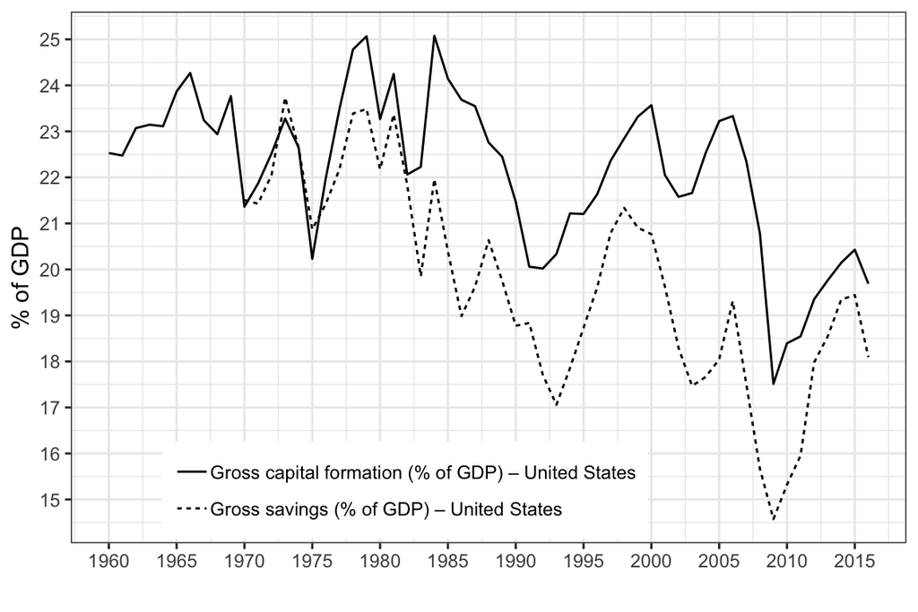

Gross Savings and Investment (WDI)

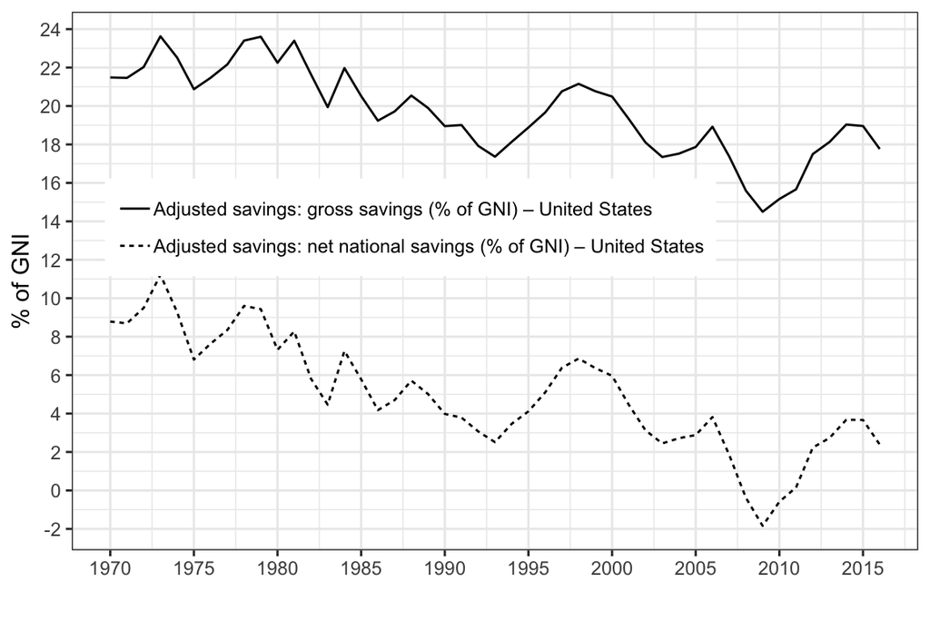

Net Savings and Gross savings (WDI)

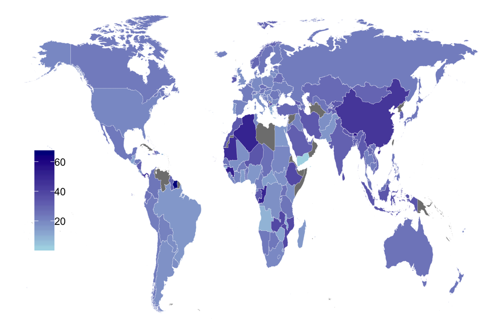

Investment (share of GDP), 2016

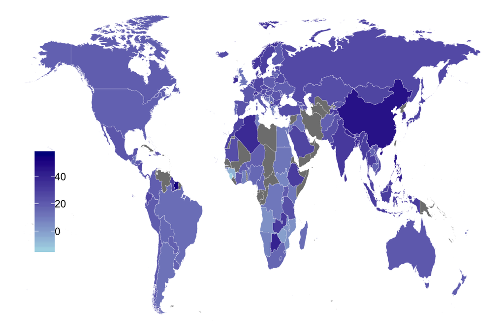

Gross Saving (share of GDP), 2016

# Readings - To go further

[Humans 1, Robots 0, *Wall Street Journal*, October 6, 2013.](https://www.wsj.com/articles/humans-1-robots-0-1381098947?tesla=y)